# Student Scores

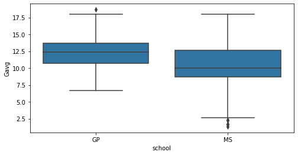

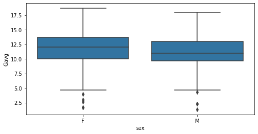

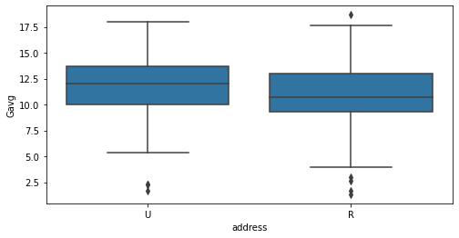

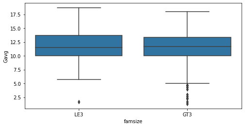

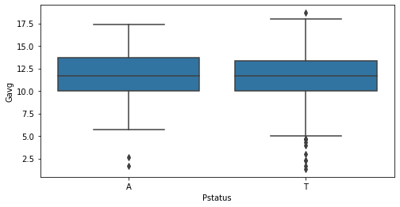

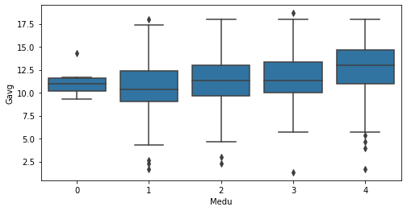

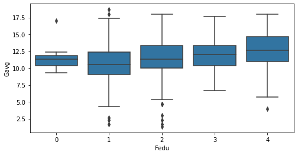

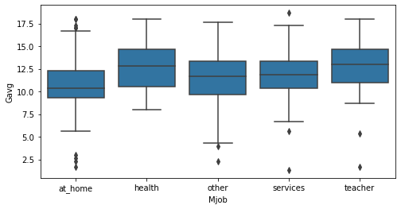

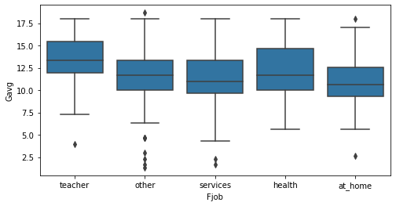

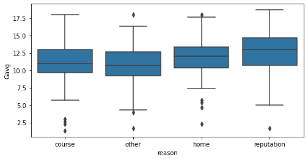

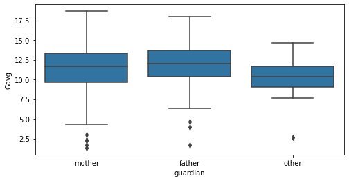

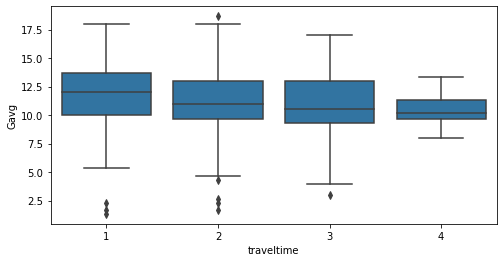

[15 more figures not shown]

```python
for v in categoric_vars:
    fig, ax = plt.subplots(figsize = [8, 4])
    sb.boxplot(data = students, x = v, y = 'Gavg',  color = base_color)
```

The results of these box plots are very interesting! Now we start to see some trends in our data. And we start to learn what features of the data affect the grades. For example we see clearly from the box plot of travel time that systematically, the less time a student needs to travel to his or her school the better on average that they perfrom. We also see that there is a strong effect of the students desire to continue or not to persue higher education and their academic performance.

More interesingly we can see that some social metrics have a considerable effect on students performance. For example we see that the higher the education level of the students' parents is the more likely they are to do well at school. And we see that the children of teachers do better than children of parents in other professions.

And from the personal habits factors, we can see that the students who go out moderately (class 2, the next to lowest class) have on average better performance than other students who go out either too little or too much.

### Summary of observations

From the graphs present above in our bivariate exploration I would like to provide the following notes refelcting on the results in view of my earlier expectations.

I will start first by stating all the features which show some effect (when I say shows some effect this means that the median, and the five number summaries of each level of this variable eaither increase or decrease systematically in as we move in one direction, in the case of ordinal variables, or from level to the other, in the case of nominal varaibels.)

If we are to make a machine learning model, I would recommend that these variable be assigned higher weights in prediction or be the only ones to be used. But for the porpuses of our analysis, finding the factors which can effect the students performance, we have different considerations and not all factors can be treated as useful.

Firstly, there are the factors which only present can not, with only the information available to us in this study, be generalized to give any conclusions about education quality in general. These variables are:

1. **School.**
2. **Address.**
3. **Sex.**

The first two are not useful for our study at all, maybe they only reflect school quality, neighborhood quality, to make sure of that we need further information. But they cannot generalize to a useful conclusion about educational systems. Unless The school with the higher grades distribution has a systematic difference in their educational systems. Which in turn suggest adapting their version of an educational system.

The third of the three, the gender of the students, might suggest that girls are better at learning languages than boys. So that boys might need more attention in such subjects.

Secondly there are social factors which affect the students grades, these can be presented to parents and schools in order to utilize them to encourage certain traits from parents or family in general. Those are:

1. **Mother And Father Education.**
2. **Mother And Father Jobs.**
3. **Family Relations.**

Better family relations enhance students' performance. And the higher the educational level of the parents the better the kids perform. The last observation can be taken into consideration and students of parents with lower education levels be given more attention for example. Lastly we could ask teachers what they do more with their children and see if education systems can be adapted to provide similar care or attention, as it is shown that it is associated with higher grade distributions.

The rest of the factors can be reasonably be in the control of the students. And hence we can present them to the students as suggestions to make them more likely to be able to het higher grades. Also they can be presented to parents and people in autherity as well, I will give a rationale for this shortly. These variables are:

1. **Travel Time.**
2. **Study Time.**
3. **Activities**
4. **Higher Education**
5. **Go Out.**
6. **Daily Alchohol Use.**

The messages which we can give to students from studying this dataset (although it is not statistically verified to be signifcant, which we need to do, but this is the scope of our study for now) -- the messages are:

1. Study more. Very obviously :"D if you study more you are gonna get better results.
2. Go to a school neer your home. The higher the travel time the less your performance is expected to be.
3. Aim high. Having a goal for your study will likely affect your performance positively.
4. Balance you time between studying and going out and doing other activities. This point is very interesting for investigation in the multivariate section, in order to learn what combinations are best.
5. Limit your use of alchohol on week days. Students who use alchohol more on week days perform more poorly.

These findings are going to guide our invistigation in the next section. Especially that we did not find strong correlations between numeric variables so the multivariate exploration we need to do is regarding the categorical variables.

And although the results from earlier bivariate explorations are quite promising, I would like to make sure that these results can not be clearer if we perform some axis transformation. And as I suspect it likely that some effects can double the grades or multiply them by a factor close to 2 (I don't have a solid justification by 2 seems quite good for the task as it is the smallest integer that can be a base for a log as well).

Therefore, I will explore next the same plots with the average grades but this time on a transformed log sale.

```python
# compute the logarithm of price to make multivariate plotting easier
def log_trans(x, inverse = False):
    """ quick function for computing log and power operations """
    if not inverse:
        return np.log2(x)
    else:
        return np.power(2, x)
```

```python
# create log grade variable
for g in grades:
    students['log_'+g] = students[g].apply(log_trans)

for g in grades:
    students.drop(students[np.isinf(students['log_'+g])].index, inplace = True)
```

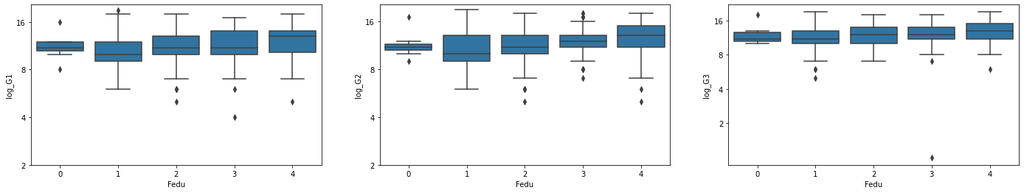

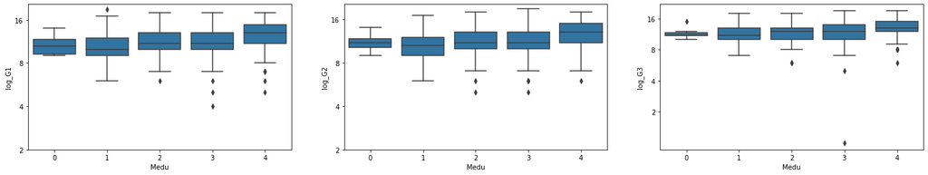

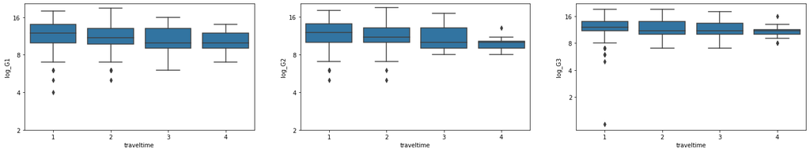

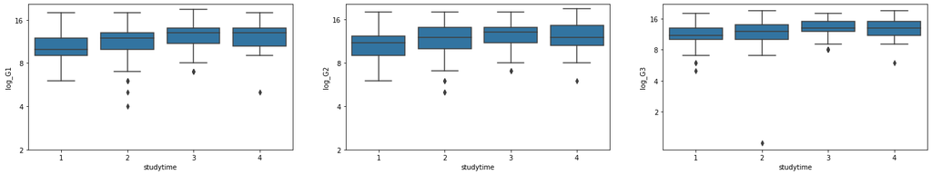

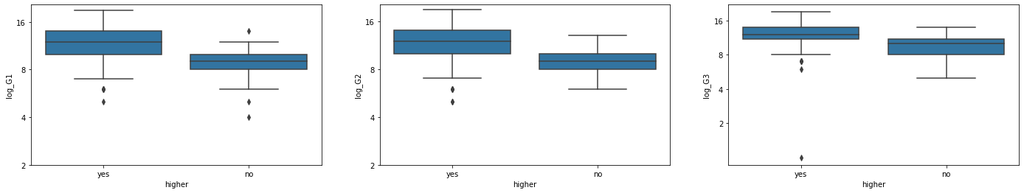

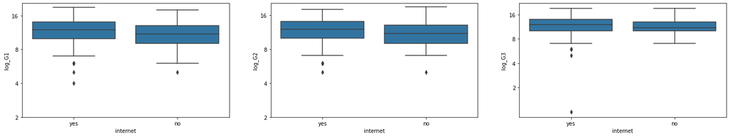

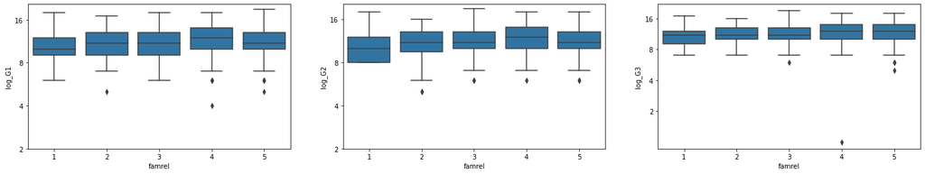

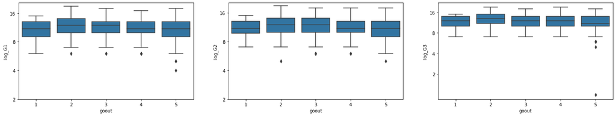

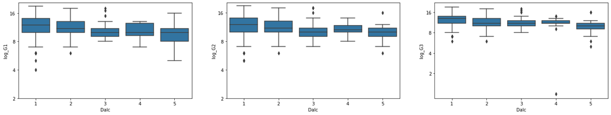

```python
# as these are the variables of strongest effect, these are the most promising in this investigation
vars_of_interest = ['Fedu', 'Medu', 'traveltime', 'studytime', 'higher', 'internet', 'famrel', 'goout', 'Dalc']

n_figures = len(vars_of_interest)

for v in vars_of_interest:
    fig, ax = plt.subplots(ncols = 3, figsize = [24, 4])
    for i, g in enumerate(grades):
        sb.boxplot(data = students, x = v, y = 'log_'+g, ax = ax[i], color = base_color)
        ax[i].set_yticks(log_trans(np.array([2, 4, 8, 16])))
        ax[i].set_yticklabels([2, 4, 8, 16])
```

Most of the results confirm indead the relations we saw earlier. Yet it does not provide new information. So this is a dead end and from here I continue with multivariate exploration.

## Multivariate Exploration

As we have seen from the bivariate exploration that the numerical features do not have almost any correlation with the target features, I will restrict my investigation in this section to multivariate exploration of pairs of categorical variables with the target features. And I will try to systematically go through them in order to extract as much information as we can from this dataset in our topic.

I will focus on the variables which we found from the previous section have the most effect on the target features; the grades.

```python
# in order to cut down lots of works
# as this function will be the one to use in this section
# create plots of two categorical variables with the target features
def grades_with(x_prop, c_prop):
    """
    Draw a pointplot of two properties with grades.
    x_prop: variable name from students to be on the x axis.
    c_prop: variable name from students for color.
    """
    fig, ax = plt.subplots(figsize = [12, 4])
    sb.pointplot(data = students, x = x_prop, y = 'Gavg', hue = c_prop,
                       palette = 'Blues', linestyles = '', dodge = 0.4)
```

I will first invistigate the features that can add to our understanding of students' habits and behaviours that leed to obtaining better grades.

To achieve that I will invistigate these features are with `studytime`:

1. **Travel Time.**
2. **Activities**
3. **Higher Education**
4. **Go Out.**
5. **Daily Alchohol Use.**

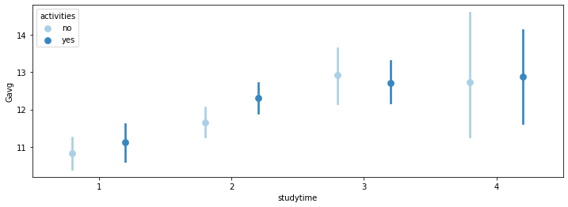

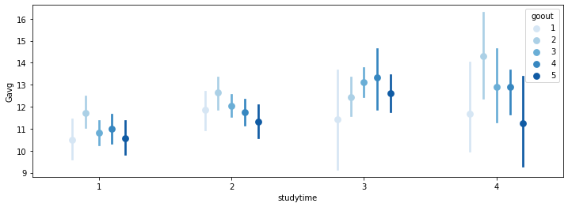

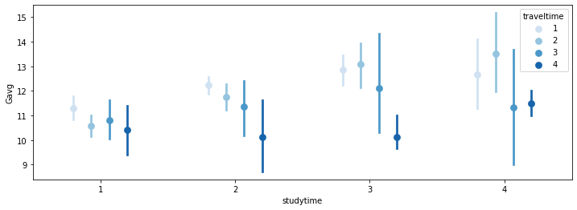

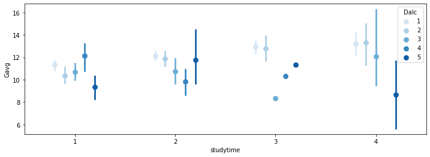

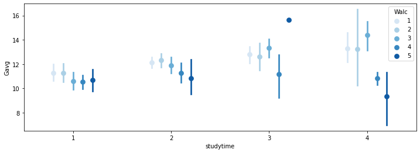

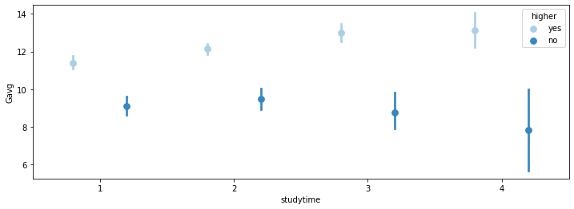

```python
vars_of_interest = ['activities', 'goout', 'traveltime', 'Dalc', 'Walc' , 'higher']

for var in vars_of_interest:
    grades_with('studytime', var)
```